# Relatório - Aprendizagem Estatística

Luigi Pavarini de Lima - NºUSP:11844642

# Leitura e Apresentação da Base de Dados

No código a seguir, realizamos a leitura e apresentação da base de dados, um passo fundamental em qualquer análise de dados. Primeiramente, carregamos o conjunto de dados a partir de um arquivo chamado “train.csv” usando a função read_csv. Após a leitura dos dados, usamos a função str para examinar a estrutura do data frame, com a opção give.attr=FALSE para não mostrar os atributos.

A importância de ler e avaliar a natureza dos dados é fundamental para entender a qualidade e a confiabilidade das informações disponíveis.

```r
df_train <- read_csv("train.csv")
str(df_train,give.attr=FALSE,list.len = 10)
```

```
## spc_tbl_ [1,460 × 81] (S3: spec_tbl_df/tbl_df/tbl/data.frame)
##  $ Id           : num [1:1460] 1 2 3 4 5 6 7 8 9 10 ...
##  $ MSSubClass   : num [1:1460] 60 20 60 70 60 50 20 60 50 190 ...
##  $ MSZoning     : chr [1:1460] "RL" "RL" "RL" "RL" ...
##  $ LotFrontage  : num [1:1460] 65 80 68 60 84 85 75 NA 51 50 ...
##  $ LotArea      : num [1:1460] 8450 9600 11250 9550 14260 ...
##  $ Street       : chr [1:1460] "Pave" "Pave" "Pave" "Pave" ...
##  $ Alley        : chr [1:1460] NA NA NA NA ...
##  $ LotShape     : chr [1:1460] "Reg" "Reg" "IR1" "IR1" ...
##  $ LandContour  : chr [1:1460] "Lvl" "Lvl" "Lvl" "Lvl" ...
##  $ Utilities    : chr [1:1460] "AllPub" "AllPub" "AllPub" "AllPub" ...
##   [list output truncated]
```

```r
df_test <- read_csv("test.csv")
str(df_test,give.attr=FALSE,list.len = 10)
```

```
## spc_tbl_ [1,459 × 80] (S3: spec_tbl_df/tbl_df/tbl/data.frame)
##  $ Id           : num [1:1459] 1461 1462 1463 1464 1465 ...
##  $ MSSubClass   : num [1:1459] 20 20 60 60 120 60 20 60 20 20 ...
##  $ MSZoning     : chr [1:1459] "RH" "RL" "RL" "RL" ...
##  $ LotFrontage  : num [1:1459] 80 81 74 78 43 75 NA 63 85 70 ...
##  $ LotArea      : num [1:1459] 11622 14267 13830 9978 5005 ...
##  $ Street       : chr [1:1459] "Pave" "Pave" "Pave" "Pave" ...
##  $ Alley        : chr [1:1459] NA NA NA NA ...
##  $ LotShape     : chr [1:1459] "Reg" "IR1" "IR1" "IR1" ...
##  $ LandContour  : chr [1:1459] "Lvl" "Lvl" "Lvl" "Lvl" ...
##  $ Utilities    : chr [1:1459] "AllPub" "AllPub" "AllPub" "AllPub" ...
##   [list output truncated]
```

Notamos nesse sentido que temos apenas dados de duas naturezas: Numéricos e Categóricos. Além disso, logo de cara, percebemos que existem alguns dados faltantes nas bases de dados acima, e vamos avaliar caso a caso a melhor forma que podemos manipular ou tratar isso.

Vale ressaltar que cada natureza de dado precisa de um tratamento diferente por isso vamos separa-los a seguir.

# Manipulação e Tratamento da Base de Dados

No código a seguir, realizamos a divisão das bases de dados, uma parte contendo variáveis numéricas (df_nmrc) e outra parte contendo variáveis categóricas (df_fct).

```r
#Separando a Base em numérica e categórica
df_nmrc_train <- df_train[,sapply(df_train,is.numeric)]
df_fct_train <- df_train[,sapply(df_train,is.character)]

df_nmrc_test <- df_test[,sapply(df_test,is.numeric)]
df_fct_test <- df_test[,sapply(df_test,is.character)]
```

## Para as variáveis numéricas

Vamos agora avaliar quais colunas temos dados faltantes (NA’s) para df_nmrc_train e df_nmrc_test.

```r
# Verificar quais colunas têm valores NA em um data frame df_nmrc
colunas_com_na_train <- colSums(is.na(df_nmrc_train)) > 0
colunas_com_na_test <- colSums(is.na(df_nmrc_test)) > 0
# Selecionar os nomes das colunas com valores NA
nomes_colunas_com_na_train <- names(df_nmrc_train)[colunas_com_na_train]
nomes_colunas_com_na_test <- names(df_nmrc_test)[colunas_com_na_test]
# Exibir os nomes das colunas com valores NA
cat("Colunas com NA na base de Treino:\n",nomes_colunas_com_na_train,
    "\n\nColunas com NA na base de Teste:\n",nomes_colunas_com_na_test)
```

```
## Colunas com NA na base de Treino:
##  LotFrontage MasVnrArea GarageYrBlt
##
## Colunas com NA na base de Teste:
##  LotFrontage MasVnrArea BsmtFinSF1 BsmtFinSF2 BsmtUnfSF TotalBsmtSF BsmtFullBath BsmtHalfBath GarageYrBlt GarageCars GarageArea
```

Como quase todas as variáveis acima (menos *GarageYrBlt*) são referentes a medidas de área em pés quadrados, vamos tomar como 0 os valores Na’s, já que este valor indica justamente a ausência dessas medidas.

Além disso, *GarageYrBlt* se refere ao ano que a garagem da propriedade em questão foi construída, por conta de sua natureza numérica vou adotar como sendo igual a 0 o valor NA’s dessa variável a fim de possibilitar a estruturação do modelo, já que dessa forma a natureza do dado se mantém.

```r
# Substituir todos os valores NA por 0
df_nmrc_train <- replace(df_nmrc_train, is.na(df_nmrc_train), 0)
df_nmrc_test <- replace(df_nmrc_test, is.na(df_nmrc_test), 0)

# Verificar quais colunas têm valores NA em um data frame df_nmrc
colunas_com_na_train <- colSums(is.na(df_nmrc_train)) > 0
colunas_com_na_test <- colSums(is.na(df_nmrc_test)) > 0
# Selecionar os nomes das colunas com valores NA
nomes_colunas_com_na_train <- names(df_nmrc_train)[colunas_com_na_train]
nomes_colunas_com_na_test <- names(df_nmrc_test)[colunas_com_na_test]
# Exibir os nomes das colunas com valores NA
cat("Colunas com NA na base de Treino:\n",nomes_colunas_com_na_train,
    "\n\nColunas com NA na base de Teste:\n", nomes_colunas_com_na_test,
    "\n\nAlterações feitas com sucesso! :) ")
```

```
## Colunas com NA na base de Treino:
##
##
## Colunas com NA na base de Teste:
##
##
## Alterações feitas com sucesso! :)
```

## Para as variáveis categóricas

Vamos agora avaliar quais colunas temos dados faltantes (NA’s) para df_fct_train e df_fct_test.

```r
# Verificar quais colunas têm valores NA em um data frame df_nmrc
colunas_com_na_train <- colSums(is.na(df_fct_train)) > 0
colunas_com_na_test <- colSums(is.na(df_fct_test)) > 0
# Selecionar os nomes das colunas com valores NA
nomes_colunas_com_na_train <- names(df_fct_train)[colunas_com_na_train]
nomes_colunas_com_na_test <- names(df_fct_test)[colunas_com_na_test]
# Exibir os nomes das colunas com valores NA
cat("Colunas com NA na base de Treino:\n",nomes_colunas_com_na_train,
    "\n\nColunas com NA na base de Teste:\n",nomes_colunas_com_na_test)
```

```
## Colunas com NA na base de Treino:
##  Alley MasVnrType BsmtQual BsmtCond BsmtExposure BsmtFinType1 BsmtFinType2 Electrical FireplaceQu GarageType GarageFinish GarageQual GarageCond PoolQC Fence MiscFeature
##
## Colunas com NA na base de Teste:
##  MSZoning Alley Utilities Exterior1st Exterior2nd MasVnrType BsmtQual BsmtCond BsmtExposure BsmtFinType1 BsmtFinType2 KitchenQual Functional FireplaceQu GarageType GarageFinish GarageQual GarageCond PoolQC Fence MiscFeature SaleType
```

Acredito que apesar da quantidade de dados faltantes em ambas as amostras (de treino e de teste) não teremos grandes problemas em representar todas as variáveis categóricas da base em variáveis dummy.

Variáveis dummy corroboram na construção de modelos para dados categóricos como neste caso já que transformam os níveis das categorias de cada variável em colunas binárias, onde cada coluna representa uma categoria e indica a presença ou ausência dessa categoria, lembrando também que a ausencia de todas as categorias daquela variável traduz os NA’s.

Além disso, unir as amostras de treino e teste antes de criar as variáveis dummy faz sentido quando a manipulação das variáveis categóricas depende da presença de todos os níveis contidos na união de ambos os conjuntos.

Isso garante que todas as categorias sejam representadas nos conjuntos de treinamento e teste, evitando problemas quando aplicarmos o modelo a novos dados.

```r
# Flag de treino para separar posteriormente
df_fct_train$Train <- "Y"
df_fct_test$Train <- "N"

# Unir as amostras de treinamento e teste em um único data frame
df_fct <- rbind(df_fct_train, df_fct_test)


# Garantir que todas as variáveis sejam tratadas como fatores
df_fct[] <- lapply(df_fct, function(x) {
    if (is.character(x)) {
      return(factor(x, levels = unique(x)))
    } else {
      return(x)
    }
  })

# Função para criar variáveis dummy
to_dummies <- function(data) {
  nam <- names(data)
  for (col in names(data)) {
    for (level in levels(data[[col]])) {
      # Cria uma nova coluna para a variavel dummy
      new_col_name <- paste(col, level, sep = "_")
      data[[new_col_name]] <- ifelse( (data[[col]] != level) |
                                        is.na(data[[col]]) , 0 , 1 )
    }
  }
  # Remove as colunas originais usadas para criar as variáveis dummy
  data <- data[as.logical(1-(colnames(data) %in% nam))]
  return(data)
}
# Aplicar a função para criar variáveis dummy
df_fct <- to_dummies(df_fct)
# Separar os conjuntos de treinamento e teste
df_fct_train <- df_fct[df_fct$Train_Y==1,]
df_fct_train <-
  df_fct_train[as.logical(1-(colnames(df_fct) %in% c("Train_Y","Train_N")))]

df_fct_test <- df_fct[df_fct$Train_Y==0,]
df_fct_test <-
  df_fct_test[as.logical(1-(colnames(df_fct) %in% c("Train_Y","Train_N")))]
```

Obtivemos então os seguintes df_fct_train e df_fct_test respectivamente

```r
str(df_fct_train, list.len = 10)
```

```
## tibble [1,460 × 252] (S3: tbl_df/tbl/data.frame)
##  $ MSZoning_RL          : num [1:1460] 1 1 1 1 1 1 1 1 0 1 ...
##  $ MSZoning_RM          : num [1:1460] 0 0 0 0 0 0 0 0 1 0 ...
##  $ MSZoning_C (all)     : num [1:1460] 0 0 0 0 0 0 0 0 0 0 ...
##  $ MSZoning_FV          : num [1:1460] 0 0 0 0 0 0 0 0 0 0 ...
##  $ MSZoning_RH          : num [1:1460] 0 0 0 0 0 0 0 0 0 0 ...
##  $ Street_Pave          : num [1:1460] 1 1 1 1 1 1 1 1 1 1 ...
##  $ Street_Grvl          : num [1:1460] 0 0 0 0 0 0 0 0 0 0 ...
##  $ Alley_Grvl           : num [1:1460] 0 0 0 0 0 0 0 0 0 0 ...
##  $ Alley_Pave           : num [1:1460] 0 0 0 0 0 0 0 0 0 0 ...
##  $ LotShape_Reg         : num [1:1460] 1 1 0 0 0 0 1 0 1 1 ...
##   [list output truncated]
```

```r
str(df_fct_test, list.len = 10)
```

```
## tibble [1,459 × 252] (S3: tbl_df/tbl/data.frame)
##  $ MSZoning_RL          : num [1:1459] 0 1 1 1 1 1 1 1 1 1 ...
##  $ MSZoning_RM          : num [1:1459] 0 0 0 0 0 0 0 0 0 0 ...
##  $ MSZoning_C (all)     : num [1:1459] 0 0 0 0 0 0 0 0 0 0 ...
##  $ MSZoning_FV          : num [1:1459] 0 0 0 0 0 0 0 0 0 0 ...
##  $ MSZoning_RH          : num [1:1459] 1 0 0 0 0 0 0 0 0 0 ...
##  $ Street_Pave          : num [1:1459] 1 1 1 1 1 1 1 1 1 1 ...
##  $ Street_Grvl          : num [1:1459] 0 0 0 0 0 0 0 0 0 0 ...
##  $ Alley_Grvl           : num [1:1459] 0 0 0 0 0 0 0 0 0 0 ...
##  $ Alley_Pave           : num [1:1459] 0 0 0 0 0 0 0 0 0 0 ...
##  $ LotShape_Reg         : num [1:1459] 1 0 0 0 0 0 0 0 1 1 ...
##   [list output truncated]
```

# Amostra de Treino, Validação e Teste

Vamos antes avaliar a dimensão da nossa amostra de treino, para sortearmos alguns indivíduos para a amostra de validação.

```r
df_ <- cbind(df_nmrc_train,df_fct_train)
dim(df_)
```

```
## [1] 1460  290
```

Temos um total de 1460 linhas e 290 colunas em nosso conjunto de dados. Para realizar a divisão tradicional de 80/20, onde 80% dos dados são destinados ao treinamento e construção do modelo, enquanto os 20% restantes são reservados para a validação, precisamos sortear aleatoriamente 1168 observações para compor a amostra de treinamento. As 292 observações restantes serão utilizadas para validar as métricas de ajuste do modelo.

```r
# Criando uma sequência de números de 1 a 1460 e armazenando no vetor 'id'
id <- seq(1:1460)

# Definindo uma semente para garantir a reprodutibilidade dos resultados
set.seed(11844642)

# Sorteando 1168 amostras sem reposição a partir do vetor 'id' e
## armazenando os índices no vetor 'train_sample_ids'
train_sample_ids <- sample(id, 1168, replace = FALSE)
```

Vamos agora dividir agora a amostra em treino, validação e teste:

```r
# Combinando data frames de treinamento numéricos e categóricos
# Selecionando amostras de treinamento com base nos IDs sorteados
df_train <- df_[df_$Id %in% train_sample_ids,]
# Selecionando amostras de validação restantes
df_validation <- df_[as.logical(1-(df_$Id %in% train_sample_ids)),]
# Combinando data frames de teste numéricos e categóricos
df_test <- cbind(df_nmrc_test,df_fct_test)

# Separando as features de treinamento e o alvo (SalePrice) para treinamento
# Recuperando as features de treinamento
x.train <- df_train[as.logical(1-(colnames(df_train) %in% c("SalePrice")))]
# Recuperando o alvo de treinamento
y.train <- df_train$SalePrice

# Separando as features de treinamento e o alvo (SalePrice) para validação
# Recuperando as features de validação
x.validation <- df_validation[as.logical(1-(colnames(df_validation)
                                            %in% c("SalePrice")))]
# Recuperando o alvo de validação
y.validation <- df_validation$SalePrice

x.test <- df_test
#y.test não existe na amostra de teste
```

Conferindo se as dimensões são compatíveis

```r
cat("Número de Linhas e Colunas de x.train:\n",dim(x.train),
    "\n\nNúmero de Linhas na coluna y.train:\n",length(y.train),
    "\n\nNúmero de Linhas e Colunas de x.validation:\n",dim(x.validation),
    "\n\nNúmero de Linhas na coluna y.validation:\n",length(y.validation),
    "\n\nNúmero de Linhas e Colunas de x.test:\n",dim(x.test),
    "\n\nAlterações feitas com sucesso! :) ")
```

```
## Número de Linhas e Colunas de x.train:
##  1168 289
##
## Número de Linhas na coluna y.train:
##  1168
##
## Número de Linhas e Colunas de x.validation:
##  292 289
##
## Número de Linhas na coluna y.validation:
##  292
##
## Número de Linhas e Colunas de x.test:
##  1459 289
##
## Alterações feitas com sucesso! :)
```

# Modelagem e Seleção de variáveis

Para o modelo proposto, que envolve a previsão de preços de vendas de propriedades, é fundamental considerar vários fatores antes de escolher os parâmetros. Dado que a variável resposta é contínua e não possui limite superior no suporte da distribuição, o uso da família gaussiana parece bastante coerente, uma vez que essa está comumente associada a modelos de regressão linear.

## Step AIC

```r
# Ajuste o modelo inicial
model_full <- glm(SalePrice ~. , data=df_train,family = gaussian)
summary(model_full)
```

```
##
## Call:
## glm(formula = SalePrice ~ ., family = gaussian, data = df_train)
##
## Deviance Residuals:
##     Min       1Q   Median       3Q      Max
## -171356    -8932      334     8707   171356
##
## Coefficients: (40 not defined because of singularities)
##                         Estimate Std. Error t value Pr(>|t|)
## (Intercept)            4.579e+05  1.178e+06   0.389 0.697702
## Id                     1.443e+00  1.723e+00   0.837 0.402603
## MSSubClass            -7.163e+01  9.410e+01  -0.761 0.446709
## LotFrontage            2.168e+01  2.583e+01   0.839 0.401583
## LotArea                5.174e-01  1.199e-01   4.315 1.77e-05 ***
## OverallQual            6.849e+03  1.153e+03   5.942 3.99e-09 ***
## OverallCond            6.060e+03  9.625e+02   6.297 4.71e-10 ***
## YearBuilt              2.827e+02  8.650e+01   3.268 0.001122 **
## YearRemodAdd           8.496e+01  6.262e+01   1.357 0.175178
## MasVnrArea             1.085e+01  6.689e+00   1.622 0.105109
## BsmtFinSF1             3.921e+01  5.930e+00   6.612 6.42e-11 ***
## BsmtFinSF2             3.526e+01  1.054e+01   3.347 0.000850 ***
## BsmtUnfSF              2.146e+01  5.460e+00   3.930 9.14e-05 ***
## TotalBsmtSF                   NA         NA      NA       NA
## `1stFlrSF`             4.137e+01  6.231e+00   6.640 5.38e-11 ***
## `2ndFlrSF`             6.074e+01  6.269e+00   9.688  < 2e-16 ***
## LowQualFinSF          -5.366e+00  2.088e+01  -0.257 0.797264
## GrLivArea                     NA         NA      NA       NA
## BsmtFullBath           1.658e+03  2.177e+03   0.762 0.446393
## BsmtHalfBath          -1.607e+02  3.316e+03  -0.048 0.961343
## FullBath               2.846e+03  2.392e+03   1.190 0.234468
## HalfBath               3.054e+02  2.294e+03   0.133 0.894122
## BedroomAbvGr          -2.513e+03  1.491e+03  -1.686 0.092204 .
## KitchenAbvGr          -2.062e+04  7.406e+03  -2.785 0.005466 **
## TotRmsAbvGrd           3.194e+02  1.078e+03   0.296 0.767134
## Fireplaces             8.569e+03  2.835e+03   3.023 0.002575 **
## GarageYrBlt            1.130e-01  7.045e+01   0.002 0.998721
## GarageCars             4.866e+03  2.596e+03   1.874 0.061252 .
## GarageArea             1.468e+01  9.139e+00   1.606 0.108571
## WoodDeckSF             1.693e+01  6.377e+00   2.655 0.008066 **
```

[output cut: 255 more lines]

```
## SaleCondition_Abnorml  3.586e+03  7.142e+03   0.502 0.615783
## SaleCondition_Partial         NA         NA      NA       NA
## SaleCondition_AdjLand  2.299e+04  1.808e+04   1.272 0.203773
## SaleCondition_Alloca  -3.812e+03  1.124e+04  -0.339 0.734612
## SaleCondition_Family          NA         NA      NA       NA
## ---
## Signif. codes:  0 '***' 0.001 '**' 0.01 '*' 0.05 '.' 0.1 ' ' 1
##
## (Dispersion parameter for gaussian family taken to be 485632442)
##
##     Null deviance: 6.8345e+12  on 1167  degrees of freedom
## Residual deviance: 4.4581e+11  on  918  degrees of freedom
## AIC: 26896
##
## Number of Fisher Scoring iterations: 2
```

```r
# Carregue a biblioteca MASS se ainda não estiver carregada
library(MASS)
```

```r
# Crie o modelo null
model_null <- glm(SalePrice ~ 1, data = df_train, family = gaussian)

# Realize a seleção de variáveis para frente (forward stepwise)
# model_forward <- stepAIC(model_null, direction = "forward",
#                         scope=list(lower=model_null, upper=model_full))

# A fim de poupar tempo comentei o método acima mas o modelo com as
## variáveis selecionadas é o seguinte:

model_forward <- glm(formula = SalePrice ~
      OverallQual + GrLivArea + BsmtQual_Ex + RoofMatl_ClyTile +
      BsmtFinSF1 + GarageCars + Condition2_PosN + KitchenQual_Ex +
      MSSubClass + YearBuilt + OverallCond + LotArea + Neighborhood_NoRidge +
      BedroomAbvGr + Neighborhood_StoneBr + BsmtExposure_Gd +
      Neighborhood_NridgHt + Neighborhood_Crawfor + RoofMatl_WdShngl +
      SaleType_New + PoolQC_Ex + ExterQual_Ex + SaleCondition_Normal +
      HeatingQC_Ex + Neighborhood_Somerst + BsmtExposure_Av + Functional_Typ +
      Fireplaces + Condition1_Norm + PoolQC_Gd + TotalBsmtSF + Street_Pave +
      Neighborhood_BrkSide + Neighborhood_Mitchel + Exterior1st_BrkFace +
      WoodDeckSF + GarageQual_Ex + BldgType_2fmCon + `2ndFlrSF` +
      LotConfig_CulDSac + Condition2_PosA + GarageCond_Ex + LowQualFinSF +
      Functional_Sev + KitchenAbvGr + GarageYrBlt + BsmtFinType1_GLQ +
      Fence_GdPrv + SaleType_Con + BsmtFinSF2 + MasVnrArea +
      HouseStyle_2.5Unf + Condition1_Artery + Condition1_RRAe +
      LandSlope_Sev + ExterCond_Fa + LotConfig_FR2 + SaleCondition_AdjLand +
      Neighborhood_NPkVill + Functional_Maj1 + Foundation_Wood +
      LotConfig_FR3 + ExterCond_TA + FullBath + Neighborhood_NWAmes +
      GarageArea + Neighborhood_NAmes + Neighborhood_Edwards + LotFrontage +
      Heating_Wall + `MSZoning_C (all)` + Neighborhood_OldTown +
      LandContour_Bnk + GarageType_2Types + Exterior2nd_Plywood +
      ScreenPorch + Utilities_AllPub + RoofMatl_Membran + BsmtFinType2_ALQ +
      Heating_OthW + BldgType_Duplex + ExterQual_Fa + LandContour_Low +
      Condition2_RRAe,
    family = gaussian, data = df_train)

summary(model_forward)
```

```
##
## Call:
## glm(formula = SalePrice ~ OverallQual + GrLivArea + BsmtQual_Ex +
##     RoofMatl_ClyTile + BsmtFinSF1 + GarageCars + Condition2_PosN +
##     KitchenQual_Ex + MSSubClass + YearBuilt + OverallCond + LotArea +
##     Neighborhood_NoRidge + BedroomAbvGr + Neighborhood_StoneBr +
##     BsmtExposure_Gd + Neighborhood_NridgHt + Neighborhood_Crawfor +
##     RoofMatl_WdShngl + SaleType_New + PoolQC_Ex + ExterQual_Ex +
##     SaleCondition_Normal + HeatingQC_Ex + Neighborhood_Somerst +
##     BsmtExposure_Av + Functional_Typ + Fireplaces + Condition1_Norm +
##     PoolQC_Gd + TotalBsmtSF + Street_Pave + Neighborhood_BrkSide +
##     Neighborhood_Mitchel + Exterior1st_BrkFace + WoodDeckSF +
##     GarageQual_Ex + BldgType_2fmCon + `2ndFlrSF` + LotConfig_CulDSac +
##     Condition2_PosA + GarageCond_Ex + LowQualFinSF + Functional_Sev +
##     KitchenAbvGr + GarageYrBlt + BsmtFinType1_GLQ + Fence_GdPrv +
##     SaleType_Con + BsmtFinSF2 + MasVnrArea + HouseStyle_2.5Unf +
##     Condition1_Artery + Condition1_RRAe + LandSlope_Sev + ExterCond_Fa +
##     LotConfig_FR2 + SaleCondition_AdjLand + Neighborhood_NPkVill +
##     Functional_Maj1 + Foundation_Wood + LotConfig_FR3 + ExterCond_TA +
##     FullBath + Neighborhood_NWAmes + GarageArea + Neighborhood_NAmes +
##     Neighborhood_Edwards + LotFrontage + Heating_Wall + `MSZoning_C (all)` +
##     Neighborhood_OldTown + LandContour_Bnk + GarageType_2Types +
##     Exterior2nd_Plywood + ScreenPorch + Utilities_AllPub + RoofMatl_Membran +
##     BsmtFinType2_ALQ + Heating_OthW + BldgType_Duplex + ExterQual_Fa +
##     LandContour_Low + Condition2_RRAe, family = gaussian, data = df_train)
##
## Deviance Residuals:
##     Min       1Q   Median       3Q      Max
## -173161    -8524      698     9655   173161
##
## Coefficients:
##                         Estimate Std. Error t value Pr(>|t|)
## (Intercept)           -6.963e+05  9.414e+04  -7.396 2.80e-13 ***
## OverallQual            6.183e+03  9.402e+02   6.576 7.50e-11 ***
## GrLivArea              5.181e+01  4.028e+00  12.861  < 2e-16 ***
## BsmtQual_Ex            2.105e+04  3.223e+03   6.531 1.01e-10 ***
## RoofMatl_ClyTile      -6.333e+05  3.196e+04 -19.812  < 2e-16 ***
## BsmtFinSF1             1.713e+01  2.198e+00   7.791 1.55e-14 ***
## GarageCars             6.105e+03  2.231e+03   2.736 0.006319 **
## Condition2_PosN       -2.069e+05  1.662e+04 -12.450  < 2e-16 ***
```

[output cut: 72 more lines]

```
## Heating_OthW          -2.380e+04  1.619e+04  -1.470 0.141867
## BldgType_Duplex        1.209e+04  6.782e+03   1.783 0.074907 .
## ExterQual_Fa           1.295e+04  7.755e+03   1.669 0.095330 .
## LandContour_Low       -8.172e+03  5.067e+03  -1.613 0.107128
## Condition2_RRAe       -3.320e+04  2.221e+04  -1.495 0.135275
## ---
## Signif. codes:  0 '***' 0.001 '**' 0.01 '*' 0.05 '.' 0.1 ' ' 1
##
## (Dispersion parameter for gaussian family taken to be 457263485)
##
##     Null deviance: 6.8345e+12  on 1167  degrees of freedom
## Residual deviance: 4.9522e+11  on 1083  degrees of freedom
## AIC: 26689
##
## Number of Fisher Scoring iterations: 2
```

```r
# Realize a seleção de variáveis para trás (backward stepwise)
# model_backward <- stepAIC(model_full, direction = "backward")
# A fim de poupar tempo comentei o método acima mas o modelo com as
## variáveis selecionadas é o seguinte:
model_backward <- glm(formula = SalePrice ~ LotArea + OverallQual +
                        OverallCond + YearBuilt + YearRemodAdd + MasVnrArea +
                        BsmtFinSF1 + BsmtFinSF2 + BsmtUnfSF + `1stFlrSF` +
                        `2ndFlrSF` + BedroomAbvGr + KitchenAbvGr +
                        Fireplaces + GarageCars + GarageArea + WoodDeckSF +
                        ScreenPorch + PoolArea + `MSZoning_C (all)` +
                        MSZoning_FV + Street_Pave + LandContour_Bnk +
                        LandContour_Low + LotConfig_Inside + LotConfig_Corner +
                        LotConfig_CulDSac + LandSlope_Gtl + LandSlope_Mod +
                        Neighborhood_CollgCr + Neighborhood_Crawfor +
                        Neighborhood_NoRidge + Neighborhood_Mitchel +
                        Neighborhood_NWAmes + Neighborhood_OldTown +
                        Neighborhood_Sawyer + Neighborhood_NridgHt +
                        Neighborhood_NAmes + Neighborhood_Edwards +
                        Neighborhood_Gilbert + Neighborhood_StoneBr +
                        Neighborhood_ClearCr + Neighborhood_NPkVill +
                        Condition1_Norm + Condition1_RRAe + Condition2_PosN +
                        Condition2_PosA + BldgType_1Fam + BldgType_2fmCon +
                        BldgType_Duplex + HouseStyle_1Story +
                        HouseStyle_2.5Unf + RoofStyle_Mansard +
                        RoofMatl_CompShg + RoofMatl_WdShngl + RoofMatl_WdShake +
                        RoofMatl_Membran + `RoofMatl_Tar&Grv` + RoofMatl_Roll +
                        Exterior1st_VinylSd + Exterior1st_MetalSd +
                        `Exterior1st_Wd Sdng` + Exterior1st_HdBoard +
                        Exterior1st_WdShing + Exterior1st_CemntBd +
                        Exterior1st_Plywood + Exterior1st_AsbShng +
                        Exterior1st_Stucco + Exterior1st_ImStucc +
                        Exterior2nd_CmentBd + Exterior2nd_ImStucc +
                        ExterQual_Gd + ExterQual_TA + ExterCond_Gd +
                        Foundation_Wood + BsmtQual_Ex + BsmtCond_TA +
                        BsmtCond_Gd + BsmtCond_Fa + BsmtExposure_Gd +
                        BsmtExposure_Av + BsmtFinType1_GLQ + BsmtFinType2_Unf +
                        BsmtFinType2_ALQ + HeatingQC_Ex + KitchenQual_Ex +
                        Functional_Typ + Functional_Min1 + Functional_Maj1 +
                        Functional_Min2 + Functional_Mod + Functional_Maj2 +
                        FireplaceQu_TA + FireplaceQu_Gd + FireplaceQu_Fa +
                        FireplaceQu_Ex + GarageType_Attchd +
                        GarageType_Detchd + GarageType_BuiltIn +
                        GarageType_CarPort + GarageType_Basment +
                        GarageType_2Types + GarageQual_Ex + GarageCond_TA +
                        GarageCond_Fa + GarageCond_Gd + GarageCond_Po +
                        PoolQC_Ex + PoolQC_Fa + PoolQC_Gd + Fence_GdPrv +
                        SaleType_New + SaleType_Con + SaleCondition_Normal +
                        SaleCondition_AdjLand,
                      family = gaussian, data = df_train)
summary(model_backward)
```

```
##
## Call:
## glm(formula = SalePrice ~ LotArea + OverallQual + OverallCond +
##     YearBuilt + YearRemodAdd + MasVnrArea + BsmtFinSF1 + BsmtFinSF2 +
##     BsmtUnfSF + `1stFlrSF` + `2ndFlrSF` + BedroomAbvGr + KitchenAbvGr +
##     Fireplaces + GarageCars + GarageArea + WoodDeckSF + ScreenPorch +
##     PoolArea + `MSZoning_C (all)` + MSZoning_FV + Street_Pave +
##     LandContour_Bnk + LandContour_Low + LotConfig_Inside + LotConfig_Corner +
##     LotConfig_CulDSac + LandSlope_Gtl + LandSlope_Mod + Neighborhood_CollgCr +
##     Neighborhood_Crawfor + Neighborhood_NoRidge + Neighborhood_Mitchel +
##     Neighborhood_NWAmes + Neighborhood_OldTown + Neighborhood_Sawyer +
##     Neighborhood_NridgHt + Neighborhood_NAmes + Neighborhood_Edwards +
##     Neighborhood_Gilbert + Neighborhood_StoneBr + Neighborhood_ClearCr +
##     Neighborhood_NPkVill + Condition1_Norm + Condition1_RRAe +
##     Condition2_PosN + Condition2_PosA + BldgType_1Fam + BldgType_2fmCon +
##     BldgType_Duplex + HouseStyle_1Story + HouseStyle_2.5Unf +
##     RoofStyle_Mansard + RoofMatl_CompShg + RoofMatl_WdShngl +
##     RoofMatl_WdShake + RoofMatl_Membran + `RoofMatl_Tar&Grv` +
##     RoofMatl_Roll + Exterior1st_VinylSd + Exterior1st_MetalSd +
##     `Exterior1st_Wd Sdng` + Exterior1st_HdBoard + Exterior1st_WdShing +
##     Exterior1st_CemntBd + Exterior1st_Plywood + Exterior1st_AsbShng +
##     Exterior1st_Stucco + Exterior1st_ImStucc + Exterior2nd_CmentBd +
##     Exterior2nd_ImStucc + ExterQual_Gd + ExterQual_TA + ExterCond_Gd +
##     Foundation_Wood + BsmtQual_Ex + BsmtCond_TA + BsmtCond_Gd +
##     BsmtCond_Fa + BsmtExposure_Gd + BsmtExposure_Av + BsmtFinType1_GLQ +
##     BsmtFinType2_Unf + BsmtFinType2_ALQ + HeatingQC_Ex + KitchenQual_Ex +
##     Functional_Typ + Functional_Min1 + Functional_Maj1 + Functional_Min2 +
##     Functional_Mod + Functional_Maj2 + FireplaceQu_TA + FireplaceQu_Gd +
##     FireplaceQu_Fa + FireplaceQu_Ex + GarageType_Attchd + GarageType_Detchd +
##     GarageType_BuiltIn + GarageType_CarPort + GarageType_Basment +
##     GarageType_2Types + GarageQual_Ex + GarageCond_TA + GarageCond_Fa +
##     GarageCond_Gd + GarageCond_Po + PoolQC_Ex + PoolQC_Fa + PoolQC_Gd +
##     Fence_GdPrv + SaleType_New + SaleType_Con + SaleCondition_Normal +
##     SaleCondition_AdjLand, family = gaussian, data = df_train)
##
## Deviance Residuals:
##     Min       1Q   Median       3Q      Max
## -173065    -9172      341     9172   173065
##
## Coefficients:
```

[output cut: 112 more lines]

```
## Fence_GdPrv           -6.435e+03  3.399e+03  -1.893 0.058573 .
## SaleType_New           2.093e+04  3.677e+03   5.691 1.63e-08 ***
## SaleType_Con           3.200e+04  1.552e+04   2.062 0.039460 *
## SaleCondition_Normal   8.869e+03  2.434e+03   3.644 0.000281 ***
## SaleCondition_AdjLand  2.596e+04  1.316e+04   1.973 0.048723 *
## ---
## Signif. codes:  0 '***' 0.001 '**' 0.01 '*' 0.05 '.' 0.1 ' ' 1
##
## (Dispersion parameter for gaussian family taken to be 454966196)
##
##     Null deviance: 6.8345e+12  on 1167  degrees of freedom
## Residual deviance: 4.7862e+11  on 1052  degrees of freedom
## AIC: 26711
##
## Number of Fisher Scoring iterations: 2
```

Nos três modelos, tivemos as medidas de AIC altas como é mostrado abaixo:

```r
fit_list <- list()
fit_list[['model_full']] <- model_full
fit_list[['model_forward']] <- model_forward
fit_list[['model_backward']] <- model_backward

results <- data.frame()
for (model in names(fit_list)) {

  predicted <-
    predict(fit_list[[model]],
            newx = x.validation,
            type = 'response')

  mse <- mean((y.validation - predicted)^2)

  temp <- data.frame(fit_name = model,
                     aic=fit_list[[model]]$aic,
                     mse=mse,
                     rmse=sqrt(mse))

  results <- rbind(results, temp)
}

results
```

```
##         fit_name      aic         mse     rmse
## 1     model_full 26896.45 13162383046 114727.4
## 2  model_forward 26689.21 13106913388 114485.4
## 3 model_backward 26711.40 13124573856 114562.5
```

## Lasso x Ridge x Elastic-net

Diferentes métodos de seleção de variáveis introduzem certo viés na modelagem para reduzir a variância na validação. Alguns exemplos desses métodos são: LASSO (L1), RIDGE (L2) e Elastic-Net, que serão utlizados a seguir.

No código a abaixo, os parâmetros escolhidos são apropriados para a tarefa de prever preços de vendas de propriedades, levando em consideração a natureza da variável de resposta e a necessidade de regularização para lidar com alta dimensionalidade e evitar overfitting.

A escolha de diferentes valores para o parâmetro alpha permite explorar várias combinações de penalidades L1 (Lasso quando = 1) e L2 (Ridge quando = 0), ajudando a encontrar o modelo mais adequado. Em relação a métrica MSE, essa é comumente usada para avaliar o desempenho do modelo durante a validação.

```r
library(glmnet)
#fit_list <- list()
for (i in 0:10) {
  fit_name <- paste("Alpha",i/10, sep="_")
  fit_list[[fit_name]] <-
    cv.glmnet(as.matrix(x.train), y.train,
              type.measure = 'mse', alpha = i/10,
              family='gaussian')
}
```

```r
results <- data.frame()
for (i in 0:10) {

  fit_name <- paste('Alpha',i/10,sep = "_")

  predicted <-
    predict(fit_list[[fit_name]],
            s=fit_list[[fit_name]]$lambda.min,
            newx = as.matrix(x.validation))

  mse_lambda_min <- mean((y.validation - predicted)^2)

  temp <- data.frame(alpha = i/10,
                     fit_name = fit_name,
                     mse_lambda=mse_lambda_min,
                     rmse_lambda=sqrt(mse_lambda_min),
                     lambda = fit_list[[fit_name]]$lambda.min,
                     log_lambda = log(fit_list[[fit_name]]$lambda.min))

  results <- rbind(results, temp)
}

head(results,11)
```

```
##    alpha  fit_name mse_lambda rmse_lambda    lambda log_lambda
## 1    0.0   Alpha_0  995983461    31559.21 56050.032  10.934000
## 2    0.1 Alpha_0.1  952480044    30862.28 15963.250   9.678044
## 3    0.2 Alpha_0.2  933719989    30556.83  8759.824   9.077931
## 4    0.3 Alpha_0.3 1042884025    32293.71  8472.670   9.044601
## 5    0.4 Alpha_0.4  886777966    29778.82  3990.813   8.291750
## 6    0.5 Alpha_0.5  925096814    30415.40  3845.558   8.254674
## 7    0.6 Alpha_0.6  812076921    28496.96  1833.808   7.514150
## 8    0.7 Alpha_0.7  940076327    30660.66  3014.640   8.011236
## 9    0.8 Alpha_0.8  909889389    30164.37  2403.474   7.784670
## 10   0.9 Alpha_0.9  847110452    29105.16  1616.124   7.387786
## 11   1.0   Alpha_1  844933007    29067.73  1454.512   7.282426
```

```r
rbind(results[1,],
      results[results$mse_lambda==min(results$mse_lambda),],
      results[length(results$alpha),])
```

```
##    alpha  fit_name mse_lambda rmse_lambda    lambda log_lambda
## 1    0.0   Alpha_0  995983461    31559.21 56050.032  10.934000
## 7    0.6 Alpha_0.6  812076921    28496.96  1833.808   7.514150
## 11   1.0   Alpha_1  844933007    29067.73  1454.512   7.282426
```

Visualizando agora o comparativo deo MSE vs a variação de Log() para os três modelos:

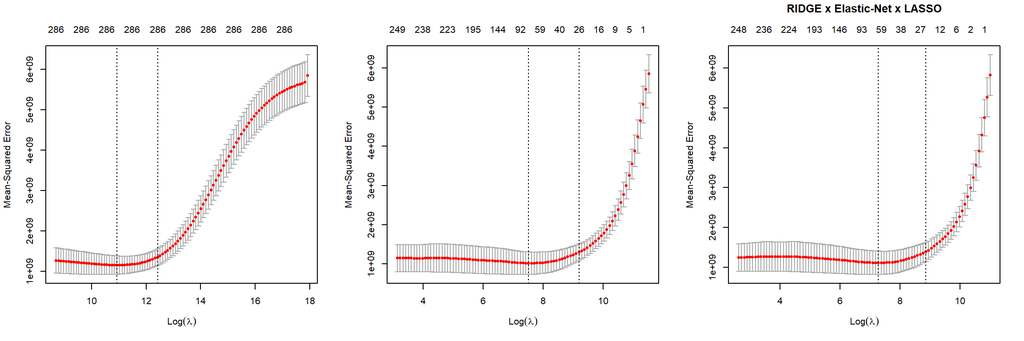

```r
par(mfrow=c(1,3))
plot(fit_list$Alpha_0)
plot(fit_list$Alpha_0.6)
plot(fit_list$Alpha_1)
title('RIDGE x Elastic-Net x LASSO', line = 3)
```

Vemos então que o EN e o Lasso tem um comportamento parecido para relação entre o log() e MSE enquanto o RIDGE tem um comportamenteo em “S”.

## Lasso x Ridge x Elastic-net (com padronização)

A aplicação de padronização, é um boa decisão a tomar em tarefas de modelagem, já que estamos lidando especialmente com um problema de alta dimensão.

A padronização, é uma forma de tentar garantir que todas as variáveis tenham uma contribuição justa para o modelo, independentemente de suas unidades de medida, evitando que a regularização afete variáveis com escalas muito diferentes.

Neste caso utilizaremos a padronização pela média e desvio padrão e não por máximos e mínimos.

```r
standardized <- function(data) {
  # Loop pelas colunas do data frame
  for (col in names(data)) {
    # Calcula a média e o desvio padrão da coluna
    media <- mean(data[[col]])
    desvio_padrao <- sd(data[[col]])

    # Verifica se o desvio padrão é zero e substitui por 1
    # por conta das preditoras que não tem variação
    if (desvio_padrao == 0) {
      data[[col]] <- (data[[col]] - media)
    } else {
      # Padroniza a coluna
      data[[col]] <- (data[[col]] - media) / desvio_padrao
    }
  }
  return(data)
}

x.train_std <- standardized(x.train)

#fit_list <- list()
for (i in 0:10) {
  fit_name <- paste("Alpha_std",i/10, sep="_")
  fit_list[[fit_name]] <-
    cv.glmnet(as.matrix(x.train_std), y.train,
              type.measure = 'mse', alpha = i/10,
              family='gaussian')
}
```

```r
x.validation_std <- standardized(x.validation)

results <- data.frame()
for (i in 0:10) {

  fit_name <- paste('Alpha_std',i/10,sep = "_")

  predicted <-
    predict(fit_list[[fit_name]],
            s=fit_list[[fit_name]]$lambda.min,
            newx = as.matrix(x.validation_std))

  mse_lambda_min <- mean((y.validation - predicted)^2)

  temp <- data.frame(alpha = i/10,
                     fit_name = fit_name,
                     mse_lambda=mse_lambda_min,
                     rmse_lambda=sqrt(mse_lambda_min),
                     lambda = fit_list[[fit_name]]$lambda.min,
                     log_lambda = log(fit_list[[fit_name]]$lambda.min))

  results <- rbind(results, temp)
}

head(results,11)
```

```
##    alpha      fit_name mse_lambda rmse_lambda    lambda log_lambda
## 1    0.0   Alpha_std_0 1190937953    34509.97 61514.841  11.027034
## 2    0.1 Alpha_std_0.1 1063084813    32604.98 13252.971   9.491977
## 3    0.2 Alpha_std_0.2 1117272687    33425.63  9613.896   9.170965
## 4    0.3 Alpha_std_0.3 1020891663    31951.40  4848.373   8.486398
## 5    0.4 Alpha_std_0.4 1027418534    32053.37  3990.813   8.291750
## 6    0.5 Alpha_std_0.5 1065134694    32636.40  3845.558   8.254674
## 7    0.6 Alpha_std_0.6 1057252848    32515.42  3204.632   8.072353
## 8    0.7 Alpha_std_0.7 1027165988    32049.43  2502.807   7.825168
## 9    0.8 Alpha_std_0.8  940133160    30661.59  1375.356   7.226468
## 10   0.9 Alpha_std_0.9 1019436089    31928.61  1946.627   7.573854
## 11   1.0   Alpha_std_1  948363675    30795.51  1207.561   7.096358
```

```r
rbind(results[1,],
      results[results$mse_lambda==min(results$mse_lambda),],
      results[length(results$alpha),])
```

```
##    alpha      fit_name mse_lambda rmse_lambda    lambda log_lambda
## 1    0.0   Alpha_std_0 1190937953    34509.97 61514.841  11.027034
## 9    0.8 Alpha_std_0.8  940133160    30661.59  1375.356   7.226468
## 11   1.0   Alpha_std_1  948363675    30795.51  1207.561   7.096358
```

Visualizando agora o comparativo deo MSE vs a variação de Log() para os três modelos:

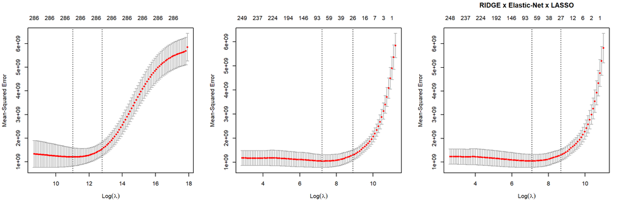

```r
par(mfrow=c(1,3))
plot(fit_list$Alpha_std_0)
plot(fit_list$Alpha_std_0.8)
plot(fit_list$Alpha_std_1)
title('RIDGE x Elastic-Net x LASSO', line = 3)
```

Vemos novamente que EN e Lasso tem um comportamento parecido para relação entre o log() e MSE enquanto o RIDGE tem um comportamenteo em “S”.

# Seleção do Modelo e Verificação dos Coeficientes

O critério de escolha estabelecido é o de menor modelo com menor MSE, já que além de uma prática comum no contexto de aprendizagem estatística um modelo com MSE menor tende a ser mais preciso na previsão dos dados, já que minimiza os desvios entre as previsões e os valores reais.

```r
coef(fit_list$Alpha_0.6, s = "lambda.min")
```

```
## 290 x 1 sparse Matrix of class "dgCMatrix"
##                                  s1
## (Intercept)           -6.351924e+05
## Id                     .
## MSSubClass            -6.762316e+01
## LotFrontage            .
## LotArea                3.451540e-01
## OverallQual            8.538553e+03
## OverallCond            3.802216e+03
## YearBuilt              2.283258e+02
## YearRemodAdd           7.968142e+01
## MasVnrArea             6.407818e+00
## BsmtFinSF1             1.303600e+01
## BsmtFinSF2             .
## BsmtUnfSF              .
## TotalBsmtSF            1.158344e+01
## 1stFlrSF               .
## 2ndFlrSF               .
## LowQualFinSF          -7.514181e+00
## GrLivArea              4.623382e+01
## BsmtFullBath           1.015231e+03
## BsmtHalfBath           .
## FullBath               1.887271e+03
## HalfBath               .
## BedroomAbvGr           .
## KitchenAbvGr          -7.269125e+03
## TotRmsAbvGrd           .
## Fireplaces             4.646185e+03
## GarageYrBlt            .
## GarageCars             5.184198e+03
## GarageArea             1.381842e+01
## WoodDeckSF             1.266186e+01
## OpenPorchSF            6.562087e-01
## EnclosedPorch          .
## 3SsnPorch              .
## ScreenPorch            8.253671e+00
## PoolArea               1.412468e+01
## MiscVal                .
## MoSold                 .
## YrSold                 .
```

[output cut: 237 more lines]

```
## SaleType_WD            .
## SaleType_New           5.676056e+03
## SaleType_COD           .
## SaleType_ConLD         .
## SaleType_ConLI         .
## SaleType_CWD           .
## SaleType_ConLw         .
## SaleType_Con           1.437861e+04
## SaleType_Oth           .
## SaleCondition_Normal   .
## SaleCondition_Abnorml -4.424714e+03
## SaleCondition_Partial  4.136034e+03
## SaleCondition_AdjLand  .
## SaleCondition_Alloca   .
## SaleCondition_Family  -5.796007e+03
```

# Previsão do Desafio

Sua previsão na amostra de teste segue do código abaixo:

```r
pred_ <- predict(fit_list$Alpha_0.6,
        s=fit_list$Alpha_0.6$lambda.min,
        newx = as.matrix(x.test))

#clipr::write_clip(pred_)
pred_
```

```
##                s1
##    [1,] 116898.91
##    [2,] 160490.83
##    [3,] 180162.47
##    [4,] 195861.82
##    [5,] 211446.78
##    [6,] 169008.19
##    [7,] 179414.10
##    [8,] 159832.93
##    [9,] 203256.32
##   [10,] 118811.30
##   [11,] 189521.01
##   [12,] 100806.27
##   [13,]  96700.88
##   [14,] 150699.06
```

[output cut: 1445 more lines]